# PROBABILIDADES

# INTRODUCCION

La probabilidad es una rama de las matemáticas que se encarga de estudiar y medir la incertidumbre. Nos permite cuantificar la posibilidad de que ocurra un determinado evento, y se utiliza ampliamente en diversas áreas como la estadística, la física, la economía, la informática, y en la vida cotidiana. En términos simples, la probabilidad es una herramienta para predecir qué tan probable es que ocurra algo. Por ejemplo, al lanzar una moneda, hay dos posibles resultados: cara o cruz. Como ambos tienen la misma posibilidad de ocurrir, se dice que la probabilidad de obtener cara es de 1/2, o 50%.

[figure not shown]

IMAGEN

# DEFINICION

La probabilidad es la expresión del grado de certeza que se tiene de que algo ocurra. Es decir, es la medida de la posibilidad de que un evento tenga lugar, a menudo expresada en términos porcentuales o fraccionarios.

De esta manera, cuando se estudia la probabilidad de algo, se estudia la frecuencia con que ocurre y se expresa teóricamente a través de una cifra comprendida entre 1 (posibilidad total de ocurrencia) y 0 (imposibilidad absoluta de ocurrencia). Así, conforme el evento sea más o menos probable, se expresa con una cifra más cercana a uno u otro extremo.

La disciplina encargada de este tipo de estudios es la teoría de la probabilidad, una rama de las matemáticas. Es muy empleada como disciplina auxiliar por otras ciencias naturales y ciencias sociales, ya que les permite manejar escenarios posibles en base a generalizaciones.

Las primeras consideraciones formales sobre esta materia provienen del siglo XVII, específicamente de la correspondencia entre Pierre de Fermat y Blaise Pascal en 1654, o de los estudios de Christiaan Huygens en 1657 y de la Kybeia de Juan Caramuel en 1649, texto hoy en día perdido.

Un fenómeno aleatorio es un suceso cuyo resultado no se puede predecir con certeza antes de que ocurra, aunque sí es posible conocer los posibles resultados. Estos fenómenos dependen del azar o la casualidad, y aunque cada vez que se repite el experimento el resultado puede ser diferente, se pueden analizar estadísticamente para determinar su probabilidad. Ejemplos comunes incluyen lanzar una moneda al aire o tirar un dado, donde no se sabe si saldrá cara o cruz, o qué número aparecerá.

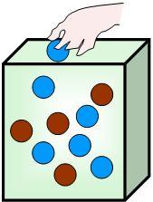

imagen

# ESPACIO MUESTRAL

El espacio muestral (representado comúnmente por la letra griega Ω o la letra S) es el conjunto de todos los resultados posibles individuales de un experimento aleatorio. Por ejemplo, al lanzar un dado, el espacio muestral es {1, 2, 3, 4, 5, 6}, ya que estas son todas las caras que pueden salir. Lanzar una moneda: El espacio muestral es {Cara, Sello}. Lanzar dos monedas: El espacio muestral es {CC, CS, SC, SS} (donde C=Cara, S=Sello). Lanzar un dado: El espacio muestral es {1, 2, 3, 4, 5, 6}.

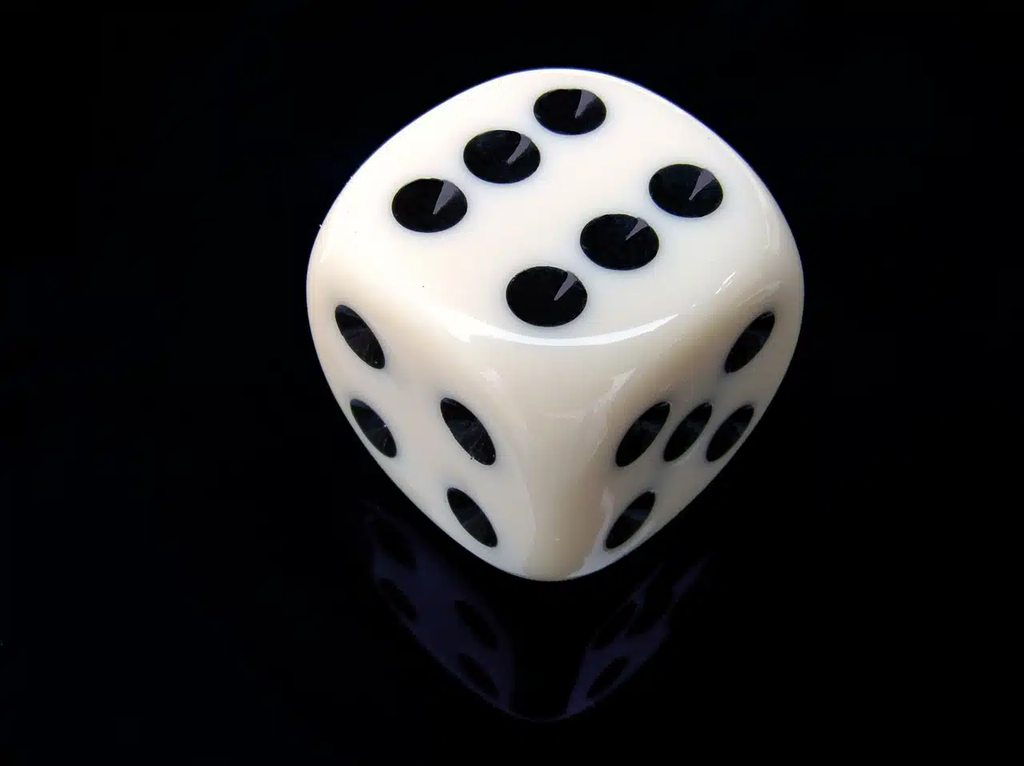

imagen

# EVENTO

La probabilidad de un evento es una medida numérica de la posibilidad de que ese evento ocurra, expresada como un valor entre 0 (imposible) y 1 (seguro). Se calcula dividiendo el número de resultados favorables entre el número total de resultados posibles en un experimento aleatorio. Fórmula general Para calcular la probabilidad de un evento (E), se utiliza la siguiente fórmula: P(E) = (Número de resultados favorables) / (Número total de resultados posibles)

EJEMPLO: ¿Cuál es la probabilidad de sacar un 4 al lanzar un dado? Resultados favorables: Solo hay un resultado favorable, que es el número 4. Resultados posibles: Los posibles resultados al lanzar un dado son {1, 2, 3, 4, 5, 6}. Por lo tanto, hay 6 resultados posibles. Cálculo: P(Sacar un 4) = 1/6. Esto significa que es poco probable, pero posible, sacar un 4.

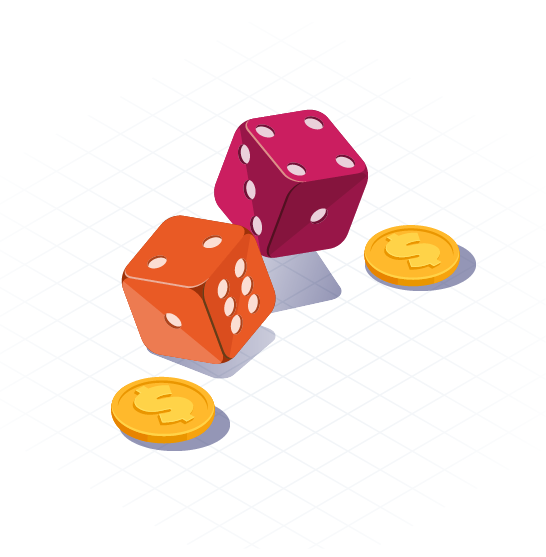

imagen

# REGLA DE ADICION

La regla de la adición o regla de la suma establece que la probabilidad de ocurrencia de cualquier evento en particular es igual a la suma de las probabilidades individuales si es que los eventos son mutuamente excluyentes, es decir, que dos no pueden ocurrir al mismo tiempo. P(A o B) = P(A) U P(B) = P(A) + P(B) si A y B son mutuamente excluyente. P(A o B) = P(A) + P(B) − P(A y B) si A y B son no excluyentes. Siendo: P(A) = probabilidad de ocurrencia del evento A. P(B) = probabilidad de ocurrencia del evento B. P(A y B)= probabilidad de ocurrencia simultánea de los eventos A y B.

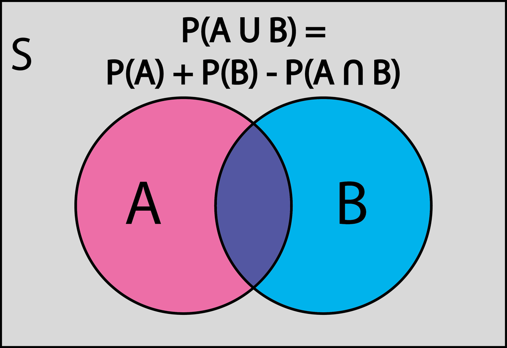

imagen

El teorema de Bayes es una fórmula matemática desarrollada por el matemático Thomas Bayes que calcula la probabilidad condicional de un evento. Permite actualizar la probabilidad de una hipótesis o evento basándose en nueva evidencia, modificando o refinando un conocimiento previo frente a información nueva, y es fundamental en campos como la estadística, medicina y finanzas para tomar decisiones bajo incertidumbre. En esencia, el teorema de Bayes nos permite determinar la probabilidad de que un evento A ocurra, sabiendo que otro evento B ya ha ocurrido. Se expresa con la siguiente fórmula: P(A|B) = [P(B|A) * P(A)] / P(B)

Donde: P(A|B): Es la probabilidad de que el evento A ocurra, dado que el evento B ya ocurrió (probabilidad a posteriori). P(B|A): Es la probabilidad de que el evento B ocurra, dado que el evento A ocurrió (probabilidad condicional). P(A): Es la probabilidad previa de que el evento A ocurra, antes de considerar la nueva evidencia (probabilidad a priori). P(B): Es la probabilidad de que el evento B ocurra (probabilidad de la evidencia).

# CONCLUSION

La probabilidad es una herramienta fundamental en la estadística y en la toma de decisiones bajo incertidumbre. Permite estimar la posibilidad de que ocurra un evento y proporciona una base lógica para analizar situaciones aleatorias en diversos contextos, como los juegos de azar, la economía, la medicina, la ingeniería y la ciencia. Comprender los conceptos básicos de probabilidad —como eventos, espacio muestral, probabilidad condicional e independencia— es esencial para interpretar datos y predecir resultados de manera informada. En resumen, el estudio de la probabilidad no solo desarrolla el pensamiento lógico y analítico, sino que también tiene aplicaciones prácticas muy amplias en la vida cotidiana y en múltiples disciplinas profesionales.